# Stat627-03

Zaiwei Liu

Nov 1, 2015

# 0 Prepare the Data and Packages

```r
Data <- read.delim(file = "http://www.stat.ubc.ca/~jenny/notOcto/STAT545A/examples/gapminder/data/gapminderDataFiveYear.txt")
require(plyr, quietly=T)
require(dplyr, quietly=T)
require(ggplot2, quietly=T)
options(scipen=999)  # Disable scientific notation (the default value is scipen=0)
```

# 1 Factor Management

## (a) Drop Oceania.

For the fact that there’re only two countries in Oceania, we’d like to drop it from our analysis here. (Sorry for Australia and New Zealand but this is what is required in this part.)

Concrete information on the data structure will be provided to learn the effect of the functions.

### i. Before removing the rows

```r
Data <- Data %>% tbl_df()  # converts data to tbl class
str(Data)
```

```
## Classes 'tbl_df', 'tbl' and 'data.frame':    1704 obs. of  6 variables:
##  $ country  : Factor w/ 142 levels "Afghanistan",..: 1 1 1 1 1 1 1 1 1 1 ...
##  $ year     : int  1952 1957 1962 1967 1972 1977 1982 1987 1992 1997 ...
##  $ pop      : num  8425333 9240934 10267083 11537966 13079460 ...
##  $ continent: Factor w/ 5 levels "Africa","Americas",..: 3 3 3 3 3 3 3 3 3 3 ...
##  $ lifeExp  : num  28.8 30.3 32 34 36.1 ...
##  $ gdpPercap: num  779 821 853 836 740 ...
```

We can see that before removing the rows, there’re totally 1704 rows of observation in the data set, while the factor `country` has 142 levels and `continent` has 5 levels.

### ii. After removing the rows

```r
Data1 <- Data %>% filter(!(continent %in% "Oceania"))
str(Data1)
```

```
## Classes 'tbl_df', 'tbl' and 'data.frame':    1680 obs. of  6 variables:
##  $ country  : Factor w/ 142 levels "Afghanistan",..: 1 1 1 1 1 1 1 1 1 1 ...
##  $ year     : int  1952 1957 1962 1967 1972 1977 1982 1987 1992 1997 ...
##  $ pop      : num  8425333 9240934 10267083 11537966 13079460 ...
##  $ continent: Factor w/ 5 levels "Africa","Americas",..: 3 3 3 3 3 3 3 3 3 3 ...
##  $ lifeExp  : num  28.8 30.3 32 34 36.1 ...
##  $ gdpPercap: num  779 821 853 836 740 ...
```

After removing the rows from Oceania, the number of rows now becomes 1680, while the levels of the two factors are still 142 and 5 separately.

### iii. After Dropping Levels

```r
Data2 <- Data1 %>% droplevels()
str(Data2)
```

```
## Classes 'tbl_df', 'tbl' and 'data.frame':    1680 obs. of  6 variables:
##  $ country  : Factor w/ 140 levels "Afghanistan",..: 1 1 1 1 1 1 1 1 1 1 ...
##  $ year     : int  1952 1957 1962 1967 1972 1977 1982 1987 1992 1997 ...
##  $ pop      : num  8425333 9240934 10267083 11537966 13079460 ...
##  $ continent: Factor w/ 4 levels "Africa","Americas",..: 3 3 3 3 3 3 3 3 3 3 ...
##  $ lifeExp  : num  28.8 30.3 32 34 36.1 ...
##  $ gdpPercap: num  779 821 853 836 740 ...
```

After applying `droplevels()` function to the data, then the numbers of levels of the affected factors change. Now, the level of `country` turns to be 140 and the level of `continent` turns to be 4.

### iv. Figures

Now, we’re going to use figures with legends to show the effects of filtering and dropping levels of the data. The first one is the original violin plot we did last time, without any reordering, transformation and summaries. The second one, as a comparison, is a rather well-designed violin plot, with Oceania dropped, log-transformed, continent reordered, and the median GDP per capita is also plotted as a point in each case.

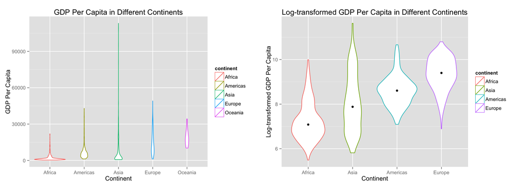

```r
Reorder <- function(dat, fun) {
  dat_new <- dat
  dat_new$continent <- dat %>% with(reorder(continent, gdpPercap, fun))
  dat_new
}
Data3 <- Reorder(Data2, "median")

A <- ggplot(Data) + geom_violin(aes(continent, gdpPercap, color=continent)) +
  xlab("Continent") + ylab("GDP Per Capita") +
  ggtitle("GDP Per Capita in Different Continents")
B <- ggplot(Data3) + geom_violin(aes(continent,log(gdpPercap),color=continent)) +
  xlab("Continent") + ylab("Log-transformed GDP Per Capita") +
  ggtitle("Log-transformed GDP Per Capita in Different Continents") +
  stat_summary(aes(continent, log(gdpPercap)), fun.y="median", geom="point")
multiplot(A, B, cols=2)
```

Apparently, the second plot is more natural and informative compared to the first one.

## (b) Reorder Factors

Last time, we’ve fitted linear regressions and got the LOOCV MSE for each country. For this part, we’re going to reorder the factor `continent`, based on the median MSE in each continent. As suggested on JB’s website, there’re four ways to arrange/reorder the factor, and we’re going to integrate them into a single principled funciton.

```r
arrange_order <- function(dat, type) {
  dat1 <- dat
  if (type==1) dat1 <- dat %>% arrange(mse)
  else if (type==2) dat1 <- dat %>% mutate(continent = reorder(continent, mse, median))
  else if (type==3) dat1 <- dat %>% mutate(continent = reorder(continent, mse, median)) %>% arrange(continent)
  else dat1 <- dat %>% mutate(continent = reorder(continent, mse, median)) %>% arrange(mse)
  dat1
}
MSE1 <- arrange_order(MSE, type=1)
MSE2 <- arrange_order(MSE, type=2)
MSE3 <- arrange_order(MSE, type=3)
MSE4 <- arrange_order(MSE, type=4)
```

### i. Post_arrange

The first type, simply arranging the data, will just mutate the order of the rows, but won’t change the order of the factor `continent`. Such an arrangement will have no effect on the figure.

```r
MSE1 %>% head()
MSE1 %>% str()
```

```
## Source: local data frame [6 x 3]
##
##       country        mse continent
##        (fctr)      (dbl)    (fctr)
## 1 Switzerland 0.05195338    Europe
## 2      Sweden 0.05361022    Europe
## 3      France 0.06641551    Europe
## 4      Canada 0.07125809  Americas
## 5     Belgium 0.09440125    Europe
## 6   Argentina 0.10481647  Americas
## Classes 'tbl_df', 'tbl' and 'data.frame':    142 obs. of  3 variables:
##  $ country  : Factor w/ 142 levels "Afghanistan",..: 124 123 45 21 10 5 41 44 91 15 ...
##  $ mse      : num  0.052 0.0536 0.0664 0.0713 0.0944 ...
##  $ continent: Factor w/ 5 levels "Africa","Americas",..: 4 4 4 2 4 2 1 4 4 2 ...
```

### ii. Post_reorder

The second type, simply reordering the factor, will not change the order of the rows, but the order of the factor `continent` will be changed. Such a reordering will change the plot.

```r
MSE2 %>% head()
MSE2 %>% str()
```

```
## Source: local data frame [6 x 3]
##
##       country       mse continent
##        (fctr)     (dbl)    (fctr)
## 1 Afghanistan 1.8298540      Asia
## 2     Albania 5.4165189    Europe
## 3     Algeria 2.2347460    Africa
## 4      Angola 2.5059150    Africa
## 5   Argentina 0.1048165  Americas
## 6   Australia 0.4733913   Oceania
## Classes 'tbl_df', 'tbl' and 'data.frame':    142 obs. of  3 variables:
##  $ country  : Factor w/ 142 levels "Afghanistan",..: 1 2 3 4 5 6 7 8 9 10 ...
##  $ mse      : num  1.83 5.417 2.235 2.506 0.105 ...
##  $ continent: Factor w/ 5 levels "Oceania","Europe",..: 4 2 5 5 3 1 2 4 4 2 ...
##   ..- attr(*, "scores")= num [1:5(1d)] 3.498 1.694 2.272 0.718 0.63
##   .. ..- attr(*, "dimnames")=List of 1
##   .. .. ..$ : chr  "Africa" "Americas" "Asia" "Europe" ...
```

### iii. Post_both

The third type firstly reorders the factor then arranges the data based on the order of the factor. In this way, the rows of data are organized in chunks of continents, where countries in `Oceania` are on placed on the top since they have the least median MSE. The plot will be the same as the second type.

```r
MSE3 %>% head()
MSE3 %>% str()
```

```
## Source: local data frame [6 x 3]
##
##                  country        mse continent
##                   (fctr)      (dbl)    (fctr)
## 1              Australia 0.47339133   Oceania
## 2            New Zealand 0.78706055   Oceania
## 3                Albania 5.41651893    Europe
## 4                Austria 0.19416307    Europe
## 5                Belgium 0.09440125    Europe
## 6 Bosnia and Herzegovina 6.93895455    Europe
## Classes 'tbl_df', 'tbl' and 'data.frame':    142 obs. of  3 variables:
##  $ country  : Factor w/ 142 levels "Afghanistan",..: 6 92 2 7 10 13 16 32 34 35 ...
##  $ mse      : num  0.4734 0.7871 5.4165 0.1942 0.0944 ...
##  $ continent: Factor w/ 5 levels "Oceania","Europe",..: 1 1 2 2 2 2 2 2 2 2 ...
##   ..- attr(*, "scores")= num [1:5(1d)] 3.498 1.694 2.272 0.718 0.63
##   .. ..- attr(*, "dimnames")=List of 1
##   .. .. ..$ : chr  "Africa" "Americas" "Asia" "Europe" ...
```

### iv. Swap out the argument for `arrange()`

The last type also reorders the factor first, but then arranges the data based on the mse of each country. In this way, the data are organized in ascending order of MSE. Personally, this is the one I preferred to use, and the plot here will also be the same as the second and third type.

```r
MSE4 %>% head()
MSE4 %>% str()
```

```
## Source: local data frame [6 x 3]
##
##       country        mse continent
##        (fctr)      (dbl)    (fctr)
## 1 Switzerland 0.05195338    Europe
## 2      Sweden 0.05361022    Europe
## 3      France 0.06641551    Europe
## 4      Canada 0.07125809  Americas
## 5     Belgium 0.09440125    Europe
## 6   Argentina 0.10481647  Americas
## Classes 'tbl_df', 'tbl' and 'data.frame':    142 obs. of  3 variables:
##  $ country  : Factor w/ 142 levels "Afghanistan",..: 124 123 45 21 10 5 41 44 91 15 ...
##  $ mse      : num  0.052 0.0536 0.0664 0.0713 0.0944 ...
##  $ continent: Factor w/ 5 levels "Oceania","Europe",..: 2 2 2 3 2 3 5 2 2 3 ...
##   ..- attr(*, "scores")= num [1:5(1d)] 3.498 1.694 2.272 0.718 0.63
##   .. ..- attr(*, "dimnames")=List of 1
##   .. .. ..$ : chr  "Africa" "Americas" "Asia" "Europe" ...
```

### v. Figures

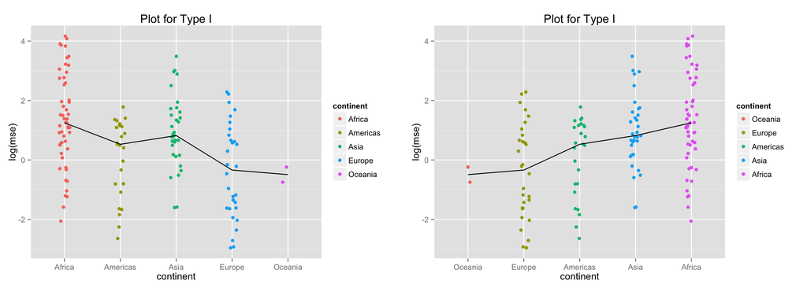

```r
A <- MSE1 %>% ggplot(aes(x = continent, y = log(mse), group = 1)) +
  geom_jitter(aes(color=continent), position = position_jitter(width = .1)) +
  stat_summary(fun.y="median", geom="line") +
  ggtitle("Plot for Type I")
B <- MSE4 %>% ggplot(aes(x = continent, y = log(mse), group = 1)) +
  geom_jitter(aes(color=continent), position = position_jitter(width = .1)) +
  stat_summary(fun.y="median", geom="line") +
  ggtitle("Plot for Type I")
multiplot(A, B, cols=2)
```

# 2 Visualization design

In this part, we remake the MSE plot we did in the last assignment, with a brandnew design of visualization. Now, the data are log-transformed, reordered, and represented in facets. The function here is a generalization of the situation, by passing the arguments to `ggplot`.

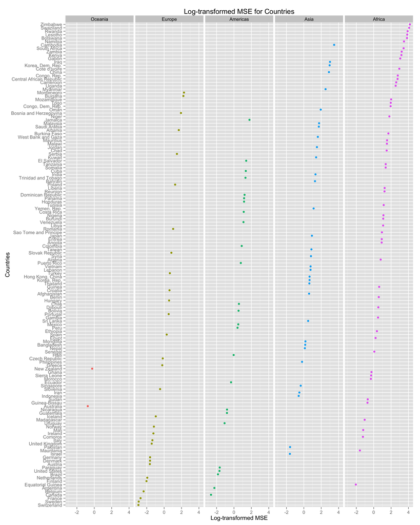

```r
MSE_plot <- function (dat, ord_fac, quant, group) {
  X <- colnames(dat)
  X[which(X==ord_fac)] <- "ord_fac"
  X[which(X==quant)] <- "quant"
  X[which(X==group)] <- "group"
  colnames(dat) <- X
  PLOT <- ggplot(dat) + facet_grid(.~group) +
    geom_point(aes(x = log(quant), y = reorder(ord_fac, log(quant)), color=group))
  PLOT
}
MSE_plot(MSE4, ord_fac = "country", quant = "mse", group = "continent") +
  xlab("Log-transformed MSE") + ylab("Countries") +
  ggtitle("Log-transformed MSE for Countries") + theme(legend.position="none")
```